# NO MORE WASTED SPACE

The Case for a Sacramento Vacancy Tax

[figure not shown]

Citywide Briefing, with District 3 Context for Councilmember Karina Talamantes VacancyFee.org

The Problem

## Vacancy Is a Choice, Not a Circumstance

For a lot of property owners, an empty building or lot in Sacramento isn't a failure to find a tenant. It's a business model. When land appreciates faster than the cost of taxes and interest, sitting on it empty can earn more than renting it out ever would. A registration or monitoring fee won't change that math: it can catch neglect, but it does nothing to the underlying incentive that rewards speculative land-banking. A vacancy tax fixes that by putting a real cost on doing nothing, while a 90-day grace period and exemptions for active construction or bona fide use mean it never touches an owner who is actually trying to lease.

8,853

Vacant/underused  
properties citywide

$70.0M/yr

Property tax  
uplift potential

$295.7M/yr

Lost sales tax  
revenue

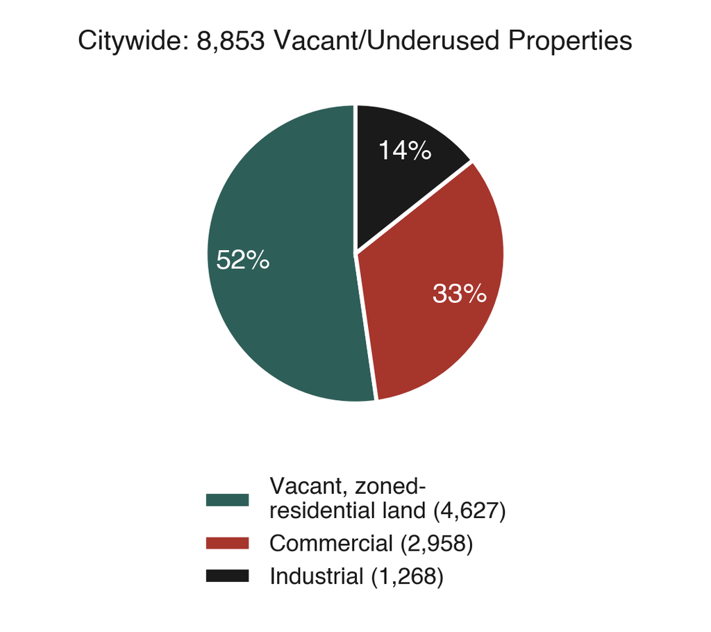

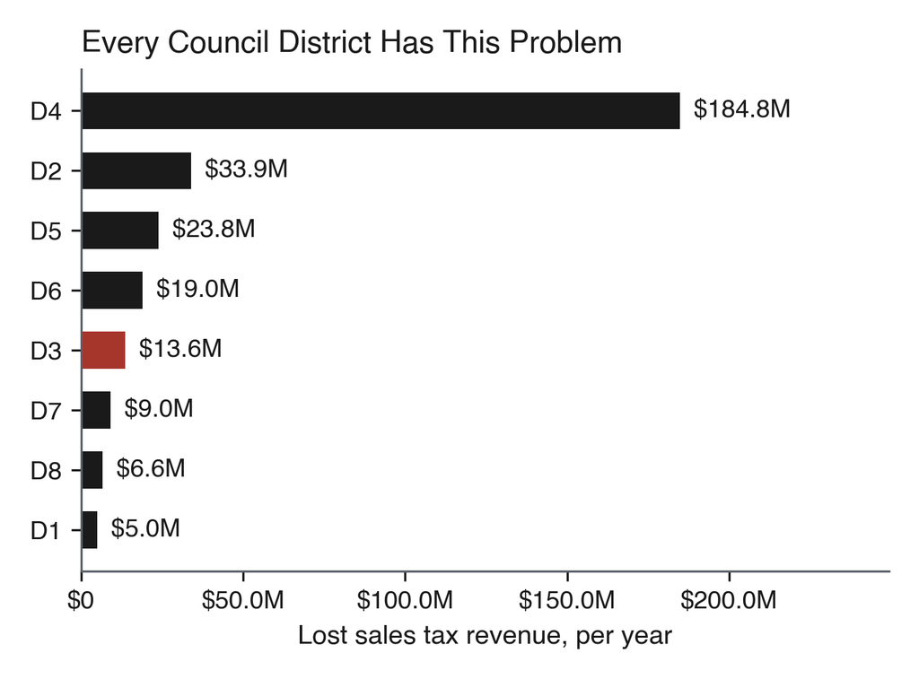

District 3 alone accounts for $13.6M/yr in lost sales tax and $2.6M/yr in property tax uplift, across 654 identified vacant or underused properties.

The Pattern

## These Properties Have Been Sitting for Years

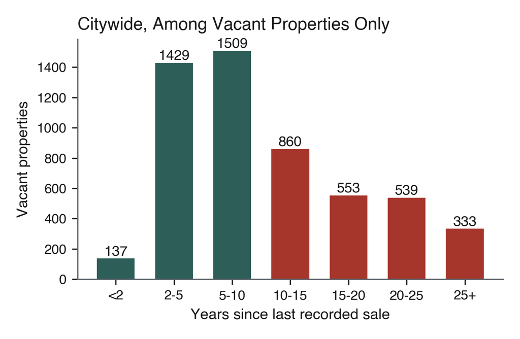

Precedent

## Other California Cities Are Already Acting

| City | Fee / Tax |
| --- | --- |
| Oakland | $3K–$6K/parcel |
| Berkeley | $3K–$6K/parcel |
| Stockton | $826/yr commercial |
| SF (Commercial) | $250–$1K/linear ft. |

District 3 Snapshot

| Vacant/underused properties | 654 |
| --- | --- |
| Property tax uplift potential | $2.6M/yr |
| Lost sales tax revenue | $13.6M/yr |

Vacant Commercial Land in District 3

| Address | Est. value | Tax uplift |
| --- | --- | --- |
| 3200 Arena Blvd | $12.8M | $118K/yr |
| 1590 W El Camino Ave | $4.4M | $40K/yr |
| 3430 Northgate Blvd | $2.7M | $30K/yr |
| 2512 River Plaza Dr | $4.1M | $29K/yr |

GET INVOLVED

Sign up, submit comments, or volunteer

VacancyFee.org